# Actividad dirigida 4: Conexión con la API del COVID19 y análisis con Pandascuando los rayos de luz no impactan la retina

# Gráfica de comparación

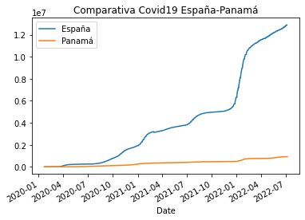

```python
pa_vs_es.plot(title="Comparativa Covid19 España-Panamá")
```

# Centro América

1. Primero voy a mostar todos los resultados de Covid-19 de los países de Centro América, como hicimos con Panamá y España.
2. Cuando ya tenemos los resultados de Nicaragua, Costa Rica, Honduras, El Salvador y Guatemala los comparamos con Panamá. Todo este proceso se hará con Pandas y luego el gráfico. (Se hará el mismo procediminto que hicimos anteriormente).

# El Salvador

Siempre empezamos verificando el Slug y el ISO.

```python
df[df['Country'] == 'El Salvador']
```

|  | Country | Slug | ISO2 |
| --- | --- | --- | --- |
| 139 | El Salvador | el-salvador | SV |

```python
url_casos_sv = 'https://api.covid19api.com/country/el-salvador/status/confirmed/live'
```

```python
df_rt_sv = pd.read_json(url_casos_sv)
```

```python
df_rt_sv
```

|  | Country | CountryCode | Province | City | CityCode | Lat | Lon | Cases | Status | Date |
| --- | --- | --- | --- | --- | --- | --- | --- | --- | --- | --- |
| 0 | El Salvador | SV |  |  |  | 13.79 | -88.9 | 0 | confirmed | 2020-01-22 00:00:00+00:00 |
| 1 | El Salvador | SV |  |  |  | 13.79 | -88.9 | 0 | confirmed | 2020-01-23 00:00:00+00:00 |
| 2 | El Salvador | SV |  |  |  | 13.79 | -88.9 | 0 | confirmed | 2020-01-24 00:00:00+00:00 |
| 3 | El Salvador | SV |  |  |  | 13.79 | -88.9 | 0 | confirmed | 2020-01-25 00:00:00+00:00 |
| 4 | El Salvador | SV |  |  |  | 13.79 | -88.9 | 0 | confirmed | 2020-01-26 00:00:00+00:00 |
| ... | ... | ... | ... | ... | ... | ... | ... | ... | ... | ... |
| 894 | El Salvador | SV |  |  |  | 13.79 | -88.9 | 169646 | confirmed | 2022-07-04 00:00:00+00:00 |
| 895 | El Salvador | SV |  |  |  | 13.79 | -88.9 | 169646 | confirmed | 2022-07-05 00:00:00+00:00 |
| 896 | El Salvador | SV |  |  |  | 13.79 | -88.9 | 169646 | confirmed | 2022-07-06 00:00:00+00:00 |
| 897 | El Salvador | SV |  |  |  | 13.79 | -88.9 | 169646 | confirmed | 2022-07-07 00:00:00+00:00 |
| 898 | El Salvador | SV |  |  |  | 13.79 | -88.9 | 169646 | confirmed | 2022-07-08 00:00:00+00:00 |

899 rows × 10 columns

# Gráfica El Salvador

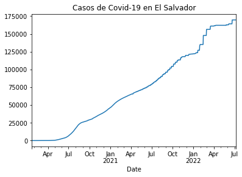

```python
casos_sv = df_rt_sv.set_index('Date')['Cases']
casos_sv.plot(title="Casos de Covid-19 en El Salvador")
```

# Nicaragua

Primer paso verificar el Slug y el ISO

```python
df[df['Country'] == 'Nicaragua']
```

|  | Country | Slug | ISO2 |
| --- | --- | --- | --- |
| 36 | Nicaragua | nicaragua | NI |

```python
url_casos_ni = 'https://api.covid19api.com/country/nicaragua/status/confirmed/live'
df_rt_ni = pd.read_json(url_casos_ni)
df_rt_ni
```

|  | Country | CountryCode | Province | City | CityCode | Lat | Lon | Cases | Status | Date |
| --- | --- | --- | --- | --- | --- | --- | --- | --- | --- | --- |
| 0 | Nicaragua | NI |  |  |  | 12.87 | -85.21 | 0 | confirmed | 2020-01-22 00:00:00+00:00 |
| 1 | Nicaragua | NI |  |  |  | 12.87 | -85.21 | 0 | confirmed | 2020-01-23 00:00:00+00:00 |
| 2 | Nicaragua | NI |  |  |  | 12.87 | -85.21 | 0 | confirmed | 2020-01-24 00:00:00+00:00 |
| 3 | Nicaragua | NI |  |  |  | 12.87 | -85.21 | 0 | confirmed | 2020-01-25 00:00:00+00:00 |
| 4 | Nicaragua | NI |  |  |  | 12.87 | -85.21 | 0 | confirmed | 2020-01-26 00:00:00+00:00 |
| ... | ... | ... | ... | ... | ... | ... | ... | ... | ... | ... |
| 893 | Nicaragua | NI |  |  |  | 12.87 | -85.21 | 14690 | confirmed | 2022-07-03 00:00:00+00:00 |
| 894 | Nicaragua | NI |  |  |  | 12.87 | -85.21 | 14690 | confirmed | 2022-07-04 00:00:00+00:00 |
| 895 | Nicaragua | NI |  |  |  | 12.87 | -85.21 | 14690 | confirmed | 2022-07-05 00:00:00+00:00 |
| 896 | Nicaragua | NI |  |  |  | 12.87 | -85.21 | 14721 | confirmed | 2022-07-06 00:00:00+00:00 |
| 897 | Nicaragua | NI |  |  |  | 12.87 | -85.21 | 14721 | confirmed | 2022-07-08 00:00:00+00:00 |

898 rows × 10 columns

# Gráfica de Nicaragua

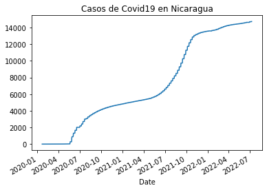

```python
url_casos_ni = 'https://api.covid19api.com/country/nicaragua/status/confirmed/live'
df_rt_ni = pd.read_json(url_casos_ni)
casos_ni = df_rt_ni.set_index('Date')['Cases']
casos_ni.plot(title="Casos de Covid19 en Nicaragua")
```

# Honduras

```python
df[df['Country'] == 'Honduras']
```

|  | Country | Slug | ISO2 |
| --- | --- | --- | --- |
| 91 | Honduras | honduras | HN |

```python
url_casos_hn = 'https://api.covid19api.com/country/honduras/status/confirmed/live'
df_rt_hn = pd.read_json(url_casos_hn)
df_rt_hn
```

|  | Country | CountryCode | Province | City | CityCode | Lat | Lon | Cases | Status | Date |
| --- | --- | --- | --- | --- | --- | --- | --- | --- | --- | --- |
| 0 | Honduras | HN |  |  |  | 15.2 | -86.24 | 0 | confirmed | 2020-01-22 00:00:00+00:00 |
| 1 | Honduras | HN |  |  |  | 15.2 | -86.24 | 0 | confirmed | 2020-01-23 00:00:00+00:00 |
| 2 | Honduras | HN |  |  |  | 15.2 | -86.24 | 0 | confirmed | 2020-01-24 00:00:00+00:00 |
| 3 | Honduras | HN |  |  |  | 15.2 | -86.24 | 0 | confirmed | 2020-01-25 00:00:00+00:00 |
| 4 | Honduras | HN |  |  |  | 15.2 | -86.24 | 0 | confirmed | 2020-01-26 00:00:00+00:00 |
| ... | ... | ... | ... | ... | ... | ... | ... | ... | ... | ... |
| 893 | Honduras | HN |  |  |  | 15.2 | -86.24 | 427718 | confirmed | 2022-07-03 00:00:00+00:00 |
| 894 | Honduras | HN |  |  |  | 15.2 | -86.24 | 427718 | confirmed | 2022-07-04 00:00:00+00:00 |
| 895 | Honduras | HN |  |  |  | 15.2 | -86.24 | 427718 | confirmed | 2022-07-05 00:00:00+00:00 |
| 896 | Honduras | HN |  |  |  | 15.2 | -86.24 | 427718 | confirmed | 2022-07-06 00:00:00+00:00 |
| 897 | Honduras | HN |  |  |  | 15.2 | -86.24 | 427718 | confirmed | 2022-07-08 00:00:00+00:00 |

898 rows × 10 columns

# Gráfica de Honduras

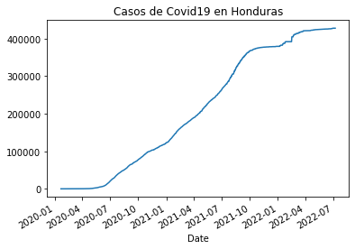

```python
url_casos_hn = 'https://api.covid19api.com/country/honduras/status/confirmed/live'
df_rt_hn = pd.read_json(url_casos_hn)
casos_hn = df_rt_hn.set_index('Date')['Cases']
casos_hn.plot(title="Casos de Covid19 en Honduras")
```

# Guatemala

```python
df[df['Country'] == 'Guatemala']
```

|  | Country | Slug | ISO2 |
| --- | --- | --- | --- |
| 239 | Guatemala | guatemala | GT |

```python
url_casos_gt = 'https://api.covid19api.com/country/guatemala/status/confirmed/live'
df_rt_gt = pd.read_json(url_casos_gt)
df_rt_gt
```

|  | Country | CountryCode | Province | City | CityCode | Lat | Lon | Cases | Status | Date |
| --- | --- | --- | --- | --- | --- | --- | --- | --- | --- | --- |
| 0 | Guatemala | GT |  |  |  | 15.78 | -90.23 | 0 | confirmed | 2020-01-22 00:00:00+00:00 |
| 1 | Guatemala | GT |  |  |  | 15.78 | -90.23 | 0 | confirmed | 2020-01-23 00:00:00+00:00 |
| 2 | Guatemala | GT |  |  |  | 15.78 | -90.23 | 0 | confirmed | 2020-01-24 00:00:00+00:00 |
| 3 | Guatemala | GT |  |  |  | 15.78 | -90.23 | 0 | confirmed | 2020-01-25 00:00:00+00:00 |
| 4 | Guatemala | GT |  |  |  | 15.78 | -90.23 | 0 | confirmed | 2020-01-26 00:00:00+00:00 |
| ... | ... | ... | ... | ... | ... | ... | ... | ... | ... | ... |
| 893 | Guatemala | GT |  |  |  | 15.78 | -90.23 | 920294 | confirmed | 2022-07-03 00:00:00+00:00 |
| 894 | Guatemala | GT |  |  |  | 15.78 | -90.23 | 921146 | confirmed | 2022-07-04 00:00:00+00:00 |
| 895 | Guatemala | GT |  |  |  | 15.78 | -90.23 | 922340 | confirmed | 2022-07-05 00:00:00+00:00 |
| 896 | Guatemala | GT |  |  |  | 15.78 | -90.23 | 927473 | confirmed | 2022-07-06 00:00:00+00:00 |
| 897 | Guatemala | GT |  |  |  | 15.78 | -90.23 | 933259 | confirmed | 2022-07-08 00:00:00+00:00 |

898 rows × 10 columns

# Gráfica de Guatemala

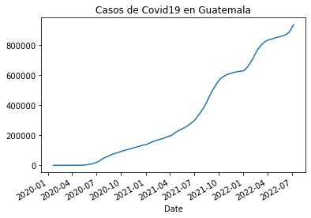

```python
url_casos_gt = 'https://api.covid19api.com/country/guatemala/status/confirmed/live'
df_rt_gt = pd.read_json(url_casos_gt)
casos_gt = df_rt_gt.set_index('Date')['Cases']
casos_gt.plot(title="Casos de Covid19 en Guatemala")
```

# Costa Rica

```python
df[df['Country'] == 'Costa Rica']
```

|  | Country | Slug | ISO2 |
| --- | --- | --- | --- |
| 242 | Costa Rica | costa-rica | CR |

```python
url_casos_cr = 'https://api.covid19api.com/country/costa-rica/status/confirmed/live'
df_rt_cr = pd.read_json(url_casos_cr)
df_rt_cr
```

|  | Country | CountryCode | Province | City | CityCode | Lat | Lon | Cases | Status | Date |
| --- | --- | --- | --- | --- | --- | --- | --- | --- | --- | --- |
| 0 | Costa Rica | CR |  |  |  | 9.75 | -83.75 | 0 | confirmed | 2020-01-22 00:00:00+00:00 |
| 1 | Costa Rica | CR |  |  |  | 9.75 | -83.75 | 0 | confirmed | 2020-01-23 00:00:00+00:00 |
| 2 | Costa Rica | CR |  |  |  | 9.75 | -83.75 | 0 | confirmed | 2020-01-24 00:00:00+00:00 |
| 3 | Costa Rica | CR |  |  |  | 9.75 | -83.75 | 0 | confirmed | 2020-01-25 00:00:00+00:00 |
| 4 | Costa Rica | CR |  |  |  | 9.75 | -83.75 | 0 | confirmed | 2020-01-26 00:00:00+00:00 |
| ... | ... | ... | ... | ... | ... | ... | ... | ... | ... | ... |
| 893 | Costa Rica | CR |  |  |  | 9.75 | -83.75 | 904934 | confirmed | 2022-07-03 00:00:00+00:00 |
| 894 | Costa Rica | CR |  |  |  | 9.75 | -83.75 | 904934 | confirmed | 2022-07-04 00:00:00+00:00 |
| 895 | Costa Rica | CR |  |  |  | 9.75 | -83.75 | 904934 | confirmed | 2022-07-05 00:00:00+00:00 |
| 896 | Costa Rica | CR |  |  |  | 9.75 | -83.75 | 904934 | confirmed | 2022-07-06 00:00:00+00:00 |
| 897 | Costa Rica | CR |  |  |  | 9.75 | -83.75 | 904934 | confirmed | 2022-07-08 00:00:00+00:00 |

898 rows × 10 columns

# Gráfica Costa Rica

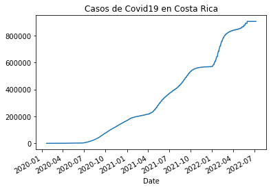

```python
url_casos_cr = 'https://api.covid19api.com/country/costa-rica/status/confirmed/live'
df_rt_cr = pd.read_json(url_casos_cr)
casos_cr = df_rt_cr.set_index('Date')['Cases']
casos_cr.plot(title="Casos de Covid19 en Costa Rica")
```

# Comparación de países centroaméricanos

- Honduras (hn)
- Panamá (pa)
- Guatemala (gt)
- El Salvador (sv)
- Nicaragua (ni)
- Costa Rica (cr)

```python
pa_vs_sv_vs_ni_vs_cr_vs_gt_vs_hn = pd.concat([casos_pa,casos_sv,casos_ni,casos_cr,casos_gt,casos_hn],axis=1)
pa_vs_sv_vs_ni_vs_cr_vs_gt_vs_hn
```

| Date | Cases | Cases | Cases | Cases | Cases | Cases |
| --- | --- | --- | --- | --- | --- | --- |
| 2020-01-22 00:00:00+00:00 | 0 | 0 | 0 | 0 | 0 | 0 |
| 2020-01-23 00:00:00+00:00 | 0 | 0 | 0 | 0 | 0 | 0 |
| 2020-01-24 00:00:00+00:00 | 0 | 0 | 0 | 0 | 0 | 0 |
| 2020-01-25 00:00:00+00:00 | 0 | 0 | 0 | 0 | 0 | 0 |
| 2020-01-26 00:00:00+00:00 | 0 | 0 | 0 | 0 | 0 | 0 |
| ... | ... | ... | ... | ... | ... | ... |
| 2022-07-03 00:00:00+00:00 | 925254 | 169646 | 14690 | 904934 | 920294 | 427718 |
| 2022-07-04 00:00:00+00:00 | 925254 | 169646 | 14690 | 904934 | 921146 | 427718 |
| 2022-07-05 00:00:00+00:00 | 925254 | 169646 | 14690 | 904934 | 922340 | 427718 |
| 2022-07-06 00:00:00+00:00 | 925254 | 169646 | 14721 | 904934 | 927473 | 427718 |
| 2022-07-08 00:00:00+00:00 | 925254 | 169646 | 14721 | 904934 | 933259 | 427718 |

898 rows × 6 columns

```python
pa_vs_sv_vs_ni_vs_cr_vs_gt_vs_hn.columns = ['Panamá', 'El Savador', 'Nicaragua', 'Costa Rica', 'Guatemala', 'Honduras']
pa_vs_sv_vs_ni_vs_cr_vs_gt_vs_hn
```

| Date | Panamá | El Savador | Nicaragua | Costa Rica | Guatemala | Honduras |
| --- | --- | --- | --- | --- | --- | --- |
| 2020-01-22 00:00:00+00:00 | 0 | 0 | 0 | 0 | 0 | 0 |
| 2020-01-23 00:00:00+00:00 | 0 | 0 | 0 | 0 | 0 | 0 |
| 2020-01-24 00:00:00+00:00 | 0 | 0 | 0 | 0 | 0 | 0 |
| 2020-01-25 00:00:00+00:00 | 0 | 0 | 0 | 0 | 0 | 0 |
| 2020-01-26 00:00:00+00:00 | 0 | 0 | 0 | 0 | 0 | 0 |
| ... | ... | ... | ... | ... | ... | ... |
| 2022-07-03 00:00:00+00:00 | 925254 | 169646 | 14690 | 904934 | 920294 | 427718 |
| 2022-07-04 00:00:00+00:00 | 925254 | 169646 | 14690 | 904934 | 921146 | 427718 |
| 2022-07-05 00:00:00+00:00 | 925254 | 169646 | 14690 | 904934 | 922340 | 427718 |
| 2022-07-06 00:00:00+00:00 | 925254 | 169646 | 14721 | 904934 | 927473 | 427718 |
| 2022-07-08 00:00:00+00:00 | 925254 | 169646 | 14721 | 904934 | 933259 | 427718 |

898 rows × 6 columns

# Gráfica del seguimiento del virus Covid-19 en Centroamérica

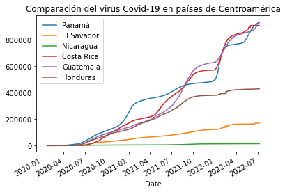

```python
pa_vs_sv_vs_ni_vs_cr_vs_gt_vs_hn.plot(title="Comparación del virus Covid-19 en países de Centroamérica")
```